# SASS

## Introducción

SASS es un preprocesador de CSS basado en Ruby, que se puede utilizar mediante los siguiente vías:

- Instalación global
- Node js
- Dart Sass
- Javascript API
- Live Sass Compiler de VSCode

Usar Sass nos da las siguientes ventajas:

- Permite que el código CSS se pueda escribir de manera mucho más rápida y sencilla.
- Facilita el mantenimiento del código.
- Permite reutilizar código.
- Facilita la creación de páginas responsivas.

Otros preprocesadores basados en Javascript son:

- Stylus
- LESS

## Tipos de archivos

- **.sass:** Utiliza una sintaxis identada, quitando el uso de “{}” y el “;” tras cada declaración.

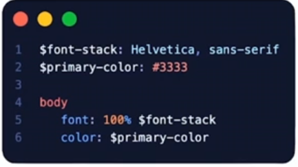

- **.scss:** Utiliza sintaxis tradicional de CSS, incluyendo el uso de “{}” y el “;” tras cada declaración.

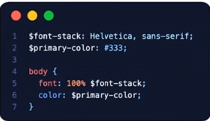

## Tips de Sass statements

### Top level

Estos solo pueden estar al inicio:

- Imports
- Definición de un Mixin
- Definición de una Función
- Módulos

También se recomienda definir variables y limpiar el proyecto con:

```
body{
    margin: 0;
    padding: 0;
}
```

### Universal

Pueden estar en cualquier parte de la hoja de estilos:

- Variables
- Estructura de control
- Reglas de @error, @warn y @debug
- Declaraciones CSS, como reglas de estilo, At-rules y Mixins.

## Selectores

Define sobre qué elementos se aplicarán un conjunto de reglas CSS y pueden ser de:

- Clase

```css
.class-name{}
```

- Id

```css
#id-name{}
```

- Tipo

```css
tag-name{}
```

- Atributo

### Nesting

Esta técnica consiste en declarar selectores dentro de otros selectores con el fin de simplificar el código al escribir los mismos en el orden definido en el html file.

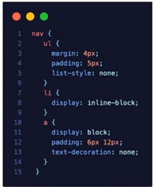

## Variables

Para definir una variable solo tenemos que iniciar con **$**, como en los siguientes ejemplos.

```css
$primary-color: blue;
$secundary-color: green;
$terciary-color: purple;
```

Estas pueden almacenar expressiones del tipo:

- Números
- Strings
- Colores
- Booleanos
- Null
- Listas
- Mapas

### Tipos de variables

- **Locales**: Son declaradas dentro de bloques “{}” y los selectores anidados pueden acceder a estas variables.
- **Global**: Son todas las variables declaras fuera de un selector y puede ser accedidas en cualquier parte de la hoja de estilos.

**Toma ventaja del nivel de scope**

Puedes usar el mismo nombre de variable para almacer valores a diferentes niveles. Esta técnica es conocida como **shadowing**.

**!global flag**

Aunque esta flag te permite modificar una variable global desde un scope local no la veo como una buena práctica.

## CSS At-rules

Se declaran con “@”, pueden realizar acciones y permiten mantener la compatibilidad con futuras versiones de CSS.

**General Rules**

- @forward: recibe como parametro una URL y nos ayuda a cargar los estilos de nuestra hoja de estilos, es muy importante hacer uso de @use para que los modulos esten disponibles en nuestra hoja de estilos.
- @use: importa modulos, estilos y funciones de otras hojas de estilos.
- @import:importa modulos, estilos y funciones pero **hace a los estilos globales**.
- @function: permite crear funciones personalizadas, que se pueden agregar a las default Sass.
- @for, @if, @each, @while: tienen que ver con estructuras de control, se pueden usar dentro de una función
- @extend: tiene que ver con el concepto de herencia.

**Compilación**

- @at-root: se encarga de cargar nuestros estilos en el root del css.
- @error, @warn @debug: asisten en el processo de compilación a CSS.
- @include: nos ayuda a invocar los **mixins**.